# Kaggle Titanic Dataset Machine Learning Model

```python
import pandas as pd
import numpy as np
import matplotlib.pyplot as plt
import seaborn as sns

from sklearn.linear_model import LogisticRegression
from sklearn.svm import SVC, LinearSVC
from sklearn.neighbors import KNeighborsClassifier
from sklearn.tree import DecisionTreeClassifier
from sklearn.ensemble import RandomForestClassifier
from sklearn.naive_bayes import GaussianNB
from sklearn.linear_model import Perceptron
from sklearn.linear_model import SGDClassifier
from sklearn.ensemble import AdaBoostClassifier
from sklearn.ensemble import GradientBoostingClassifier
from sklearn.preprocessing import MinMaxScaler
from sklearn.model_selection import KFold
from sklearn.model_selection import cross_val_score
from sklearn.model_selection import cross_val_predict
from sklearn.metrics import confusion_matrix
from sklearn.model_selection import RandomizedSearchCV
```

## Import Data

```python
train = pd.read_csv('train.csv')
test = pd.read_csv('test.csv')
both = [train,test]
train.columns
```

```
Index(['PassengerId', 'Survived', 'Pclass', 'Name', 'Sex', 'Age', 'SibSp',
       'Parch', 'Ticket', 'Fare', 'Cabin', 'Embarked'],
      dtype='object')
```

Varibles Description

```
PassengerId : Unique id number to each passenger
Survived : Passanger survive(1) or die(0)
Pclass : Passanger Class
Name : Name
Sex : Gender of passanger
Age : Age of passanger
SibSp : Number of siblings/spouses
Parch : Number of parents/children
Ticket : Number of ticket
Fare : Amount of money spend on ticket
Cabin : Cabin type
Embarked : Port where passenger embarked (C = Cherbourg, Q = Queenstown, S = Southampton)
```

Print out all numerical columns

```python
train.describe()
```

|  | PassengerId | Survived | Pclass | Age | SibSp | Parch | Fare |
| --- | --- | --- | --- | --- | --- | --- | --- |
| count | 891.000000 | 891.000000 | 891.000000 | 714.000000 | 891.000000 | 891.000000 | 891.000000 |
| mean | 446.000000 | 0.383838 | 2.308642 | 29.699118 | 0.523008 | 0.381594 | 32.204208 |
| std | 257.353842 | 0.486592 | 0.836071 | 14.526497 | 1.102743 | 0.806057 | 49.693429 |
| min | 1.000000 | 0.000000 | 1.000000 | 0.420000 | 0.000000 | 0.000000 | 0.000000 |
| 25% | 223.500000 | 0.000000 | 2.000000 | 20.125000 | 0.000000 | 0.000000 | 7.910400 |
| 50% | 446.000000 | 0.000000 | 3.000000 | 28.000000 | 0.000000 | 0.000000 | 14.454200 |
| 75% | 668.500000 | 1.000000 | 3.000000 | 38.000000 | 1.000000 | 0.000000 | 31.000000 |
| max | 891.000000 | 1.000000 | 3.000000 | 80.000000 | 8.000000 | 6.000000 | 512.329200 |

Print out all object columns

```python
train.describe(include=['O'])
```

|  | Name | Sex | Ticket | Cabin | Embarked |
| --- | --- | --- | --- | --- | --- |
| count | 891 | 891 | 891 | 204 | 889 |
| unique | 891 | 2 | 681 | 147 | 3 |
| top | Braund, Mr. Owen Harris | male | 347082 | B96 B98 | S |
| freq | 1 | 577 | 7 | 4 | 644 |

Check where there are missing values

```python
train.isnull().sum()
```

```
PassengerId      0
Survived         0
Pclass           0
Name             0
Sex              0
Age            177
SibSp            0
Parch            0
Ticket           0
Fare             0
Cabin          687
Embarked         2
dtype: int64
```

Cabin is missing a tremendous amount of data. I wonder if grouping it as 'Deck' may provide insight

```python
for df in both:
    df['Cabin'].replace(np.nan,'M',inplace=True)
    df['Deck']=df['Cabin'].str[0]
    print(df['Deck'].unique())
```

```
['M' 'C' 'E' 'G' 'D' 'A' 'B' 'F' 'T']
['M' 'B' 'E' 'A' 'C' 'D' 'F' 'G']
```

## Data Exploration

```python
def bars(data, y, vars,title):
    fig, axes = plt.subplots(1,len(vars),figsize=(15,5))
    for var, ax in zip(vars,axes.reshape(-1)):
        sns.barplot(x=var, y=y,data=data,ax=ax)
        ax.set(title=var+' Distribution')
    fig.suptitle(title)
    fig.tight_layout()
    fig.show()
```

Plot bar charts of the survival rate by different categories

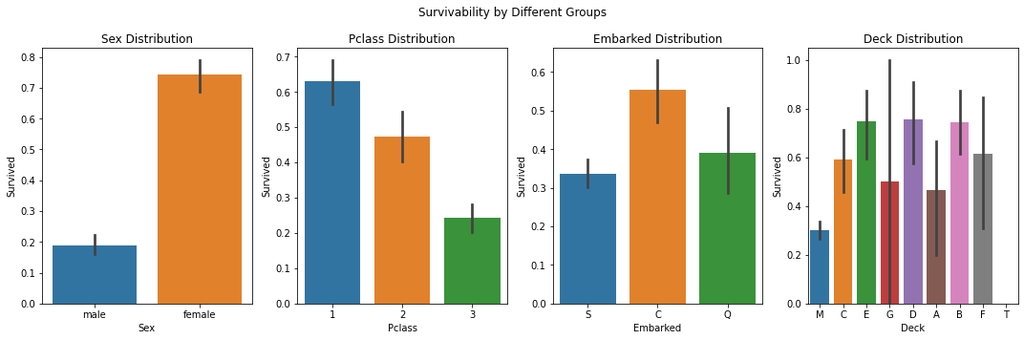

```python
vars = ['Sex','Pclass','Embarked','Deck']
bars(data=train,y='Survived',vars=vars,title='Survivability by Different Groups')
```

Plot the changes in survivability from group to group

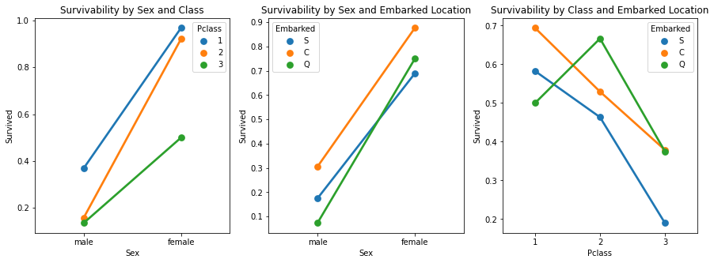

```python
fig, axes = plt.subplots(1,3,figsize=(15,5))
sns.pointplot(x='Sex', y='Survived', hue='Pclass', data=train,kind='point',ax=axes[0], ci = None)
axes[0].set_title('Survivability by Sex and Class')
sns.pointplot(x='Sex', y='Survived', hue='Embarked', data=train,kind='point',ax=axes[1], ci = None)
axes[1].set_title('Survivability by Sex and Embarked Location')
sns.pointplot(x='Pclass', y='Survived', hue='Embarked', data=train,kind='point',ax=axes[2], ci = None)
axes[2].set_title('Survivability by Class and Embarked Location')
```

```python
def hists(data, comp, vars,title):
    fig, axes = plt.subplots(2,int(round(len(vars)/2)),figsize=(20,10))
    groups = data[comp].unique()
    for var, ax in zip(vars,axes.reshape(-1)):
        for group in groups:
            sns.histplot(x=var,hue=comp,data=data,ax=ax,stat='density',kde=True)
        ax.set(title=var+' Distribution')
    fig.suptitle(title)
    fig.tight_layout()
    fig.show()
```

Plot the different distributions for the numerical variables between the survived passengers and those who did not. It is notable that younger people were more likely to survive and people who paid more for their ticket we likely to survive as well.

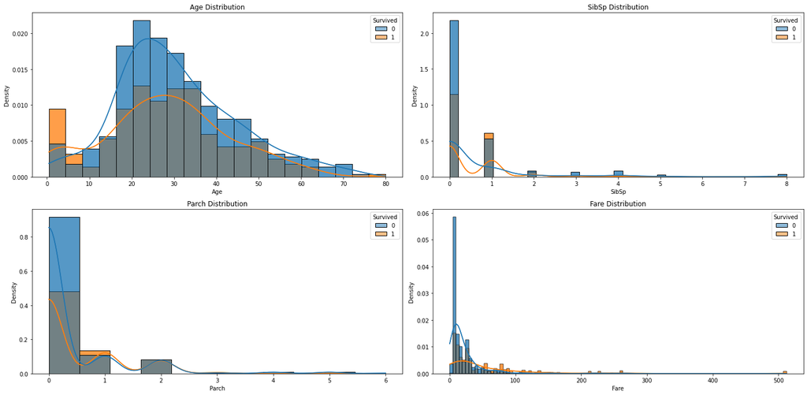

```python
hist_vars = ['Age', 'SibSp', 'Parch', 'Fare']
hists(data=train, comp = 'Survived',vars=hist_vars,title='')
```

Correlation Matrix shows that Age, SibSp, and Parch are not very correlated

```
[(16.336, 32.252], (32.252, 48.168], NaN, (48.168, 64.084], (0.34, 16.336], (64.084, 80.0]]
Categories (5, interval[float64, right]): [(0.34, 16.336] < (16.336, 32.252] < (32.252, 48.168] < (48.168, 64.084] < (64.084, 80.0]]
```

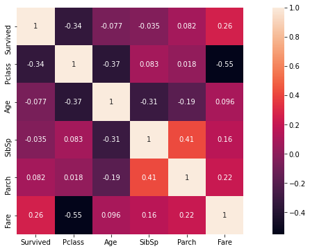

```python
plt.figure(figsize=(15,6))
sns.heatmap(train.drop('PassengerId',axis=1).corr(), square=True, annot=True)
#Looking at the variables that are less thatn .1 correlated with 'Survived' we can create Age bands to help age be a better variable
print(pd.cut(train['Age'], 5).unique())
```

## Feature creation

Creating features that will be more highly correlated with the survivability

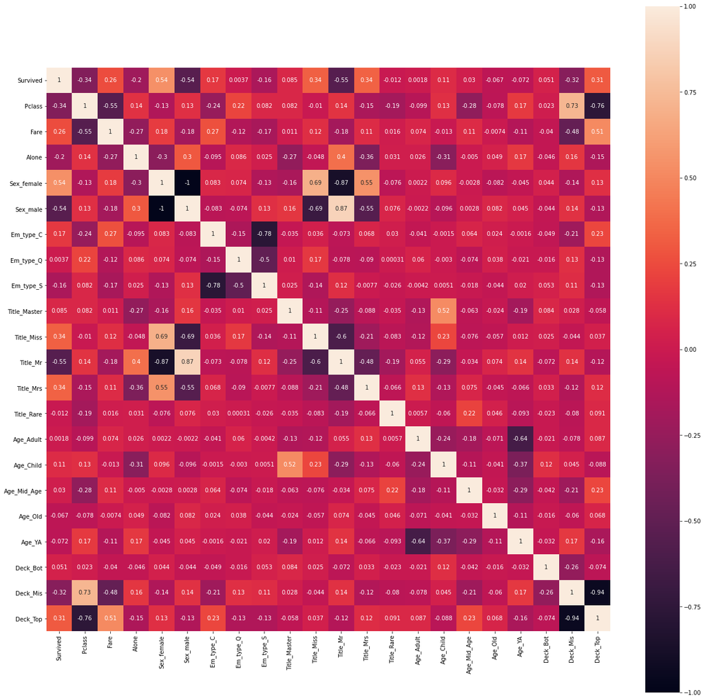

```python
trn = pd.read_csv('train.csv')
tst = pd.read_csv('test.csv')
both = [trn,tst]
cont_vars = ['Fare']

for df in both:
    #Fill in blank Embarked with the most common 'Embarked' code
    df['Embarked'] = df['Embarked'].fillna(trn['Embarked'].mode())
    #Edit create Title field and sort into categories: Master, Miss, Mrs, Mr, and Rare
    df['Title'] = df.Name.str.extract(' ([A-Za-z]+)\.', expand=False)
    df['Title'] = df['Title'].replace(['Lady', 'Countess','Capt', 'Col', 'Don', 'Dr', 'Major', 'Rev', 'Sir', 'Jonkheer', 'Dona'], 'Rare')
    df['Title'] = df['Title'].replace('Mlle', 'Miss')
    df['Title'] = df['Title'].replace('Ms', 'Miss')
    df['Title'] = df['Title'].replace('Mme', 'Mrs')
    #Fill in missing ages with a random age from the mean and std of the other ages
    age_avg = df['Age'].mean()
    age_std = df['Age'].std()
    age_null_count = df['Age'].isnull().sum()
    age_null_random_list = np.random.randint(age_avg - age_std, age_avg + age_std, size=age_null_count)
    df.loc[df['Age'].isnull(),'Age']=age_null_random_list
    df['Age'] = df['Age'].astype(int)

    #Creating age brackets
    df['Age_Group']=""
    df.loc[df['Age']<=16,'Age_Group'] = 'Child'
    df.loc[df['Age']>16,'Age_Group'] = 'YA'
    df.loc[df['Age']>32,'Age_Group'] = 'Adult'
    df.loc[df['Age']>48,'Age_Group'] = 'Mid_Age'
    df.loc[df['Age']>64,'Age_Group'] = 'Old'

    #Creating Deck variable
    df['Cabin'].replace(np.nan,'M',inplace=True)
    df['Deck']=df['Cabin'].str[0]
    df.loc[df['Deck']=='A','Deck'] = 'Top'
    df.loc[df['Deck']=='B','Deck'] = 'Top'
    df.loc[df['Deck']=='C','Deck'] = 'Top'
    df.loc[df['Deck']=='D','Deck'] = 'Top'
    df.loc[df['Deck']=='E','Deck'] = 'Top'
    df.loc[df['Deck']=='F','Deck'] = 'Bot'
    df.loc[df['Deck']=='G','Deck'] = 'Bot'
    df.loc[df['Deck']=='T','Deck'] = 'Bot'
    df.loc[df['Deck']=='M','Deck'] = 'Mis'


    #Fill in missing Fare data with median
    df['Fare'] = df['Fare'].fillna(trn['Fare'].median())
    #Add sibling and parents together for total family number
    df['Family']=df['Parch']+df['SibSp']+1
    #Add Alone column if the person was alone
    df['Alone']=0
    df.loc[df['Family']==1,'Alone']=1

#Scale the one continuous variable that we still have
scaler = MinMaxScaler(feature_range=(0,1))
trn[cont_vars] = scaler.fit_transform(trn[cont_vars])
tst[cont_vars] = scaler.fit_transform(tst[cont_vars])


#Create dummy variables for our categorival variables
trn = pd.get_dummies(trn, columns = ["Sex","Embarked","Title","Age_Group",'Deck'],prefix=["Sex","Em_type",'Title','Age','Deck'])
tst = pd.get_dummies(tst, columns = ["Sex","Embarked",'Title',"Age_Group",'Deck'],prefix=["Sex","Em_type",'Title','Age','Deck'])
#Drop unused variables
trn.drop(['Parch', 'SibSp', 'Family','Age'], axis=1,inplace=True)
tst.drop(['Parch', 'SibSp', 'Family','Age'], axis=1,inplace=True)


plt.figure(figsize=(22,22))
sns.heatmap(trn.drop('PassengerId',axis=1).corr(), square=True, annot=True)
```

## Model Testing

```python
def test_models(models,X_train,y_train,X_test):
    for clf in models:
        clf.fit(X_train, y_train)
        y_pred = clf.predict(X_test)
        acc = round(clf.score(X_train, y_train) * 100, 2)
        print(str(clf),' score: ',acc)
```

Test multiple different classification models and return the score from the training set

```python
models= [LogisticRegression(),SVC(),LinearSVC(),KNeighborsClassifier(n_neighbors=3),DecisionTreeClassifier(),RandomForestClassifier(n_estimators=100),GaussianNB(),Perceptron(max_iter=5,tol=None),SGDClassifier(max_iter=5,tol=None),GradientBoostingClassifier(),AdaBoostClassifier()]
X_train = trn.drop(['PassengerId', 'Survived', 'Name', 'Ticket','Cabin'], axis=1)
X_test =  tst.drop(['PassengerId', 'Name', 'Ticket', 'Cabin'], axis =1)
y_train = trn['Survived']

test_models(models = models, X_train=X_train, y_train=y_train, X_test=X_test)
```

```
LogisticRegression()  score:  81.93
SVC()  score:  82.94
LinearSVC()  score:  81.37
KNeighborsClassifier(n_neighbors=3)  score:  87.43
DecisionTreeClassifier()  score:  94.61
RandomForestClassifier()  score:  94.5
GaussianNB()  score:  77.22
Perceptron(max_iter=5, tol=None)  score:  79.69
SGDClassifier(max_iter=5, tol=None)  score:  78.56
GradientBoostingClassifier()  score:  88.78
AdaBoostClassifier()  score:  84.62
```

## Hyper parameter tuning

With RandomForestClassifier() being one of the best scoring tests and having good parameters to tune on, lets start with first using the Random Search CV.

```python
# Number of trees in random forest
n_estimators = [int(x) for x in np.linspace(start = 200, stop = 2000, num = 10)]
# Number of features to consider at every split
max_features = ['auto', 'sqrt']
# Maximum number of levels in tree
max_depth = [int(x) for x in np.linspace(10, 110, num = 11)]
max_depth.append(None)
# Minimum number of samples required to split a node
min_samples_split = [2, 5, 10]
# Minimum number of samples required at each leaf node
min_samples_leaf = [1, 2, 4]
# Method of selecting samples for training each tree
bootstrap = [True, False]

random_grid = {'n_estimators': n_estimators,
               'max_features': max_features,
               'max_depth': max_depth,
               'min_samples_split': min_samples_split,
               'min_samples_leaf': min_samples_leaf,
               'bootstrap': bootstrap}
```

```python
clf = RandomForestClassifier()
clf_cv = RandomizedSearchCV(estimator = clf, param_distributions = random_grid, n_iter = 100, cv = 3, verbose=2, random_state=42, n_jobs = -1)
clf_cv.fit(X_train, y_train)
y_pred = clf_cv.predict(X_test)
acc = round(clf_cv.score(X_train, y_train) * 100, 2)
print(str(clf),' score: ',acc)
print(clf_cv.best_params_)
```

```
Fitting 3 folds for each of 100 candidates, totalling 300 fits
RandomForestClassifier()  score:  90.46
{'n_estimators': 1200, 'min_samples_split': 5, 'min_samples_leaf': 2, 'max_features': 'sqrt', 'max_depth': 10, 'bootstrap': False}
```

With the parameters narrowed in on, lets now create a grid search cv to finer tune those parameters

```python
from sklearn.model_selection import GridSearchCV

# Create the parameter grid based on the results of random search
param_grid = {
    'bootstrap': [True],
    'max_depth': [5, 10, 15],
    'max_features': ['sqrt'],
    'min_samples_leaf': [2, 3, 4],
    'min_samples_split': [4, 5, 6],
    'n_estimators': [1000, 1200, 1400]
}
# Create a based model

grid_search = GridSearchCV(estimator = clf, param_grid = param_grid,
                          cv = 3, n_jobs = -1, verbose = 2)
clf = RandomForestClassifier()
clf_cv = GridSearchCV(estimator = clf, param_grid = param_grid, cv = 3, verbose=2, n_jobs = -1)
clf_cv.fit(X_train, y_train)
y_pred = clf_cv.predict(X_test)
acc = round(clf_cv.score(X_train, y_train) * 100, 2)
print(str(clf),' score: ',acc)
print(clf_cv.best_params_)
```

```
Fitting 3 folds for each of 81 candidates, totalling 243 fits
RandomForestClassifier()  score:  88.78
{'bootstrap': True, 'max_depth': 10, 'max_features': 'sqrt', 'min_samples_leaf': 2, 'min_samples_split': 5, 'n_estimators': 1000}
```

Printing the results to a submission file.

```python
test_results = pd.DataFrame({
        "PassengerId": test["PassengerId"],
        "Survived": y_pred
    })
test_results.to_csv('test_results.csv', index=False)
```

This process resulted in an accuracy of 77.272% with the test set which is in the top 20% of the competition and the top 15% if you remove all of the people that have perfect scores (most likely cheaters per Kaggle)